# `augsynth`: Estimating treatment effects with staggered adoption

### The data

To show the features of the `multisynth` function we will use data on the effects of states implementing mandatory collective bargaining agreements for public sector unions [(Paglayan, 2018)](https://onlinelibrary.wiley.com/doi/full/10.1111/ajps.12388)

```r
library(magrittr)
library(dplyr)
#devtools::install_github("ebenmichael/augsynth")
library(augsynth)
```

```r
data <- read.csv("https://dataverse.harvard.edu/api/access/datafile/:persistentId?persistentId=doi:10.7910/DVN/WGWMAV/3UHTLP", sep="\t")
```

The dataset contains several important variables that we’ll use:

- `year`, `State`: The state and year of the measurement
- `YearCBrequired`: The year that the state adopted mandatory collective bargaining
- `lnppexpend`: Log per pupil expenditures in constant 2010 $

To run `multisynth`, we need to include a treatment status column that indicates which state is treated in a given year, we call this `cbr` below. We also restrict to the years 1959-1997 where we have yearly measurements of expenditures and drop Washington D.C. and Wisconsin from the analysis.

```r
analysis_df <-  data %>%
  filter(!State %in% c("DC", "WI"),
           year >= 1959, year <= 1997) %>%
  mutate(YearCBrequired = ifelse(is.na(YearCBrequired),
                                   Inf, YearCBrequired),
           cbr = 1 * (year >= YearCBrequired))
```

## Partially pooled SCM with an intercept

To fit partially pooled synthetic controls, we need to give `multisynth` a formula of the form `outcome ~ treatment`, point it to the unit and time variables, and choose the level of partial pooling `nu`. Setting `nu = 0` fits a separate synthetic control for each treated unit and setting `nu = 1` fits fully pooled synthetic controls. If we don’t set `nu`, `multisynth` will choose a heuristic value based on how well separate synthetic controls balance the overall average. By default, `multisynth` includes an intercept shift along with the weights; we can exclude the intercept shift by setting `fixedeff = F`. We can also set the number of pre-treatment time periods (lags) that we want to balance with the `n_lags` argument and the number of post-treatment time periods (leads) that we want to estimate with the `n_leads` argument. By default `multisynth` sets `n_lags` and `n_leads` to the number of pre-treatment and post-treatment periods for the last treated unit, respectively.

```r
# with a choice of nu
ppool_syn <- multisynth(lnppexpend ~ cbr, State, year,
                        nu = 0.5, analysis_df)
# with default nu
ppool_syn <- multisynth(lnppexpend ~ cbr, State, year,
                        analysis_df)
print(ppool_syn$nu)
```

```
#> [1] 0.2606793
```

```r
ppool_syn
```

```
#>
#> Call:
#> multisynth(form = lnppexpend ~ cbr, unit = State, time = year,
#>     data = analysis_df)
#>
#> Average ATT Estimate: -0.011
```

Using the `summary` function, we’ll compute the treatment effects and standard errors and confidence intervals for all treated units as well as the average via the wild bootstrap. (This takes a bit of time so we’ll store the output) We can also change the significant level associated with the confidence intervals by setting the `alpha` argument, by default `alpha = 0.05`.

```r
ppool_syn_summ <- summary(ppool_syn)
```

We can then report the level of global and individual balance as well as estimates for the average.

```r
ppool_syn_summ
```

```
#>
#> Call:
#> multisynth(form = lnppexpend ~ cbr, unit = State, time = year,
#>     data = analysis_df)
#>
#> Average ATT Estimate (Std. Error): -0.011  (0.022)
#>
#> Global L2 Imbalance: 0.003
#> Scaled Global L2 Imbalance: 0.019
#> Percent improvement from uniform global weights: 98.1
#>
#> Individual L2 Imbalance: 0.028
#> Scaled Individual L2 Imbalance: 0.096
#> Percent improvement from uniform individual weights: 90.4
#>
#>  Time Since Treatment   Level     Estimate  Std.Error lower_bound upper_bound
#>                     0 Average -0.004280701 0.02265016 -0.04812719  0.03918665
#>                     1 Average -0.010855744 0.02112205 -0.04953833  0.03563427
#>                     2 Average  0.004379480 0.02361781 -0.04052605  0.04949603
#>                     3 Average  0.001156364 0.02402491 -0.04302200  0.05025689
#>                     4 Average -0.009304510 0.02551243 -0.05916788  0.03871195
#>                     5 Average -0.016942492 0.02450999 -0.06595845  0.03051817
#>                     6 Average -0.018504802 0.02463253 -0.06610357  0.02997095
#>                     7 Average -0.003866051 0.02849899 -0.05990166  0.04994145
#>                     8 Average -0.015834891 0.03144928 -0.08215832  0.04569073
#>                     9 Average -0.031750413 0.02910597 -0.09156672  0.02491984
#>                    10 Average -0.017838072 0.03323090 -0.08328314  0.04324588
```

| Time | Level | Estimate | Std.Error | lower_bound | upper_bound |
| --- | --- | --- | --- | --- | --- |
| 0 | Average | -0.0042807 | 0.0226502 | -0.0481272 | 0.0391866 |
| 1 | Average | -0.0108557 | 0.0211220 | -0.0495383 | 0.0356343 |
| 2 | Average | 0.0043795 | 0.0236178 | -0.0405261 | 0.0494960 |
| 3 | Average | 0.0011564 | 0.0240249 | -0.0430220 | 0.0502569 |
| 4 | Average | -0.0093045 | 0.0255124 | -0.0591679 | 0.0387119 |
| 5 | Average | -0.0169425 | 0.0245100 | -0.0659585 | 0.0305182 |

We can also visually display both the pre-treatment balance and the estimated treatment effects.

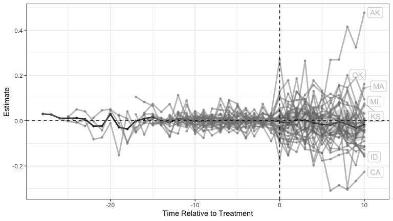

```r
plot(ppool_syn_summ)
```

And again we can hone in on the average effects.

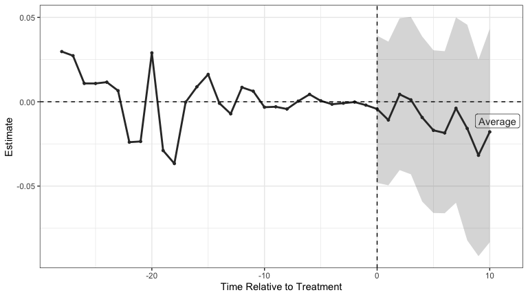

```r
plot(ppool_syn_summ, levels = "Average")
```

### Collapsing into time cohorts

We can also collapse treated units with the same treatment time into *time cohorts*, and find one synthetic control per time cohort by setting `time_cohort = TRUE`. When the number of distinct treatment times is much smaller than the number of treated units, this will run significantly faster.

```r
# with default nu
ppool_syn_time <- multisynth(lnppexpend ~ cbr, State, year,
                        analysis_df, time_cohort = TRUE)
print(ppool_syn_time$nu)
```

```
#> [1] 0.3655737
```

```r
ppool_syn_time
```

```
#>
#> Call:
#> multisynth(form = lnppexpend ~ cbr, unit = State, time = year,
#>     data = analysis_df, time_cohort = TRUE)
#>
#> Average ATT Estimate: -0.017
```

We can then compute effects for the overall average as well as for each treatment time cohort, rather than individual units.

```r
ppool_syn_time_summ <- summary(ppool_syn_time)
ppool_syn_time_summ
```

```
#>
#> Call:
#> multisynth(form = lnppexpend ~ cbr, unit = State, time = year,
#>     data = analysis_df, time_cohort = TRUE)
#>
#> Average ATT Estimate (Std. Error): -0.017  (0.022)
#>
#> Global L2 Imbalance: 0.005
#> Scaled Global L2 Imbalance: 0.018
#> Percent improvement from uniform global weights: 98.2
#>
#> Individual L2 Imbalance: 0.039
#> Scaled Individual L2 Imbalance: 0.057
#> Percent improvement from uniform individual weights: 94.3
#>
#>  Time Since Treatment   Level      Estimate  Std.Error lower_bound upper_bound
#>                     0 Average  0.0025241650 0.02279479 -0.04250201  0.04541815
#>                     1 Average -0.0155724247 0.02303371 -0.06217756  0.02755998
#>                     2 Average -0.0003873799 0.02327158 -0.04696941  0.04626441
#>                     3 Average -0.0011558505 0.02415842 -0.05032324  0.04517903
#>                     4 Average -0.0158716363 0.02545266 -0.06823646  0.03421864
#>                     5 Average -0.0272642131 0.02529692 -0.07673021  0.02336604
#>                     6 Average -0.0214783752 0.02392308 -0.06892630  0.02326231
#>                     7 Average -0.0114809345 0.02971755 -0.07068782  0.04445880
#>                     8 Average -0.0244298889 0.03201411 -0.09020416  0.03338150
#>                     9 Average -0.0464849060 0.03018660 -0.10926129  0.01170696
#>                    10 Average -0.0227462133 0.03011519 -0.08586764  0.03274486
```

| Time | Level | Estimate | Std.Error | lower_bound | upper_bound |
| --- | --- | --- | --- | --- | --- |
| 0 | Average | 0.0025242 | 0.0227948 | -0.0425020 | 0.0454181 |
| 1 | Average | -0.0155724 | 0.0230337 | -0.0621776 | 0.0275600 |
| 2 | Average | -0.0003874 | 0.0232716 | -0.0469694 | 0.0462644 |
| 3 | Average | -0.0011559 | 0.0241584 | -0.0503232 | 0.0451790 |
| 4 | Average | -0.0158716 | 0.0254527 | -0.0682365 | 0.0342186 |
| 5 | Average | -0.0272642 | 0.0252969 | -0.0767302 | 0.0233660 |

Again we can plot the effects.

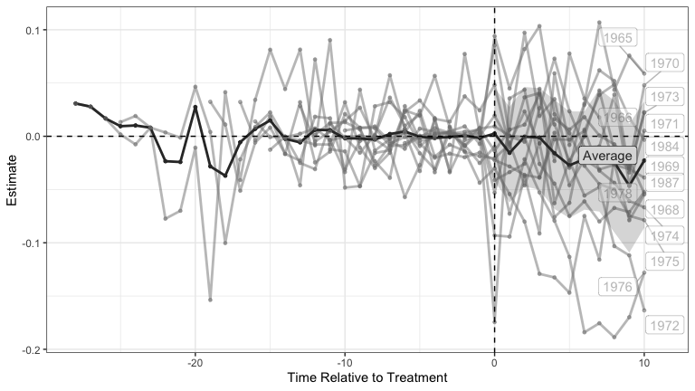

```r
plot(ppool_syn_time_summ)
```

### Including auxiliary covariates

We can also include an additional set of covariates to balance along with the pre-treatment outcomes. First, let’s create a data frame with the values of some covariates in a few different years:

```r
data %>%
  select(State, year, agr, pnwht, purban, perinc, studteachratio) %>%
  group_by(State) %>%
  summarise(perinc_1959 = perinc[year == 1959],
            studteachratio_1959 = studteachratio[year == 1959]) %>%
  # filter to lower 48 where we have data
  filter(!State %in% c("AK", "HI"))  -> cov_data
analysis_df %>%
  inner_join(cov_data, by = "State") -> analysis_df_covs
```

To include auxiliary covariates, we can add them in to the formula after `|`. This will balance the auxiliary covariates along with the pre-treatment outcomes simultanouesly. If the covariates vary during the pre-treatment periods, `multisynth` will use the average pre-treatment value. We can change this behavior by including our own custom aggregation function via the `cov_agg` argument.

```r
# with default nu
ppool_syn_cov <- multisynth(lnppexpend ~ cbr | perinc_1959 + studteachratio_1959,
                            State, year, analysis_df_covs)
print(ppool_syn_cov$nu)
```

```
#> [1] 0.2242633
```

```r
ppool_syn_cov
```

```
#>
#> Call:
#> multisynth(form = lnppexpend ~ cbr | perinc_1959 + studteachratio_1959,
#>     unit = State, time = year, data = analysis_df_covs)
#>
#> Average ATT Estimate: -0.019
```

Again we can compute effects, along with their standard errors and confidence intervals, and plot.

```r
ppool_syn_cov_summ <- summary(ppool_syn_cov)
ppool_syn_cov_summ
```

```
#>
#> Call:
#> multisynth(form = lnppexpend ~ cbr | perinc_1959 + studteachratio_1959,
#>     unit = State, time = year, data = analysis_df_covs)
#>
#> Average ATT Estimate (Std. Error): -0.019  (0.017)
#>
#> Global L2 Imbalance: 0.004
#> Scaled Global L2 Imbalance: 0.030
#> Percent improvement from uniform global weights: 97
#>
#> Individual L2 Imbalance: 0.043
#> Scaled Individual L2 Imbalance: 0.155
#> Percent improvement from uniform individual weights: 84.5
#>
#>  Time Since Treatment   Level      Estimate  Std.Error lower_bound upper_bound
#>                     0 Average -0.0002623589 0.02096636 -0.04312269  0.03794207
#>                     1 Average -0.0156460545 0.01920547 -0.05507190  0.01836590
#>                     2 Average  0.0069387466 0.01967113 -0.03354487  0.04270302
#>                     3 Average -0.0106103779 0.02086010 -0.05293509  0.03103435
#>                     4 Average -0.0194237423 0.02020958 -0.05914198  0.02250731
#>                     5 Average -0.0209125783 0.02108895 -0.06223188  0.02049553
#>                     6 Average -0.0212524266 0.02154780 -0.06421670  0.02077423
#>                     7 Average -0.0276106061 0.02298370 -0.07154688  0.01704533
#>                     8 Average -0.0278447702 0.02456472 -0.07404099  0.02095461
#>                     9 Average -0.0354975379 0.02490563 -0.08623980  0.01180405
#>                    10 Average -0.0341082006 0.02958793 -0.09257468  0.02047021
```

| Time | Level | Estimate | Std.Error | lower_bound | upper_bound |
| --- | --- | --- | --- | --- | --- |
| 0 | Average | -0.0002624 | 0.0209664 | -0.0431227 | 0.0379421 |
| 1 | Average | -0.0156461 | 0.0192055 | -0.0550719 | 0.0183659 |
| 2 | Average | 0.0069387 | 0.0196711 | -0.0335449 | 0.0427030 |
| 3 | Average | -0.0106104 | 0.0208601 | -0.0529351 | 0.0310344 |
| 4 | Average | -0.0194237 | 0.0202096 | -0.0591420 | 0.0225073 |
| 5 | Average | -0.0209126 | 0.0210890 | -0.0622319 | 0.0204955 |

Again we can plot the effects.

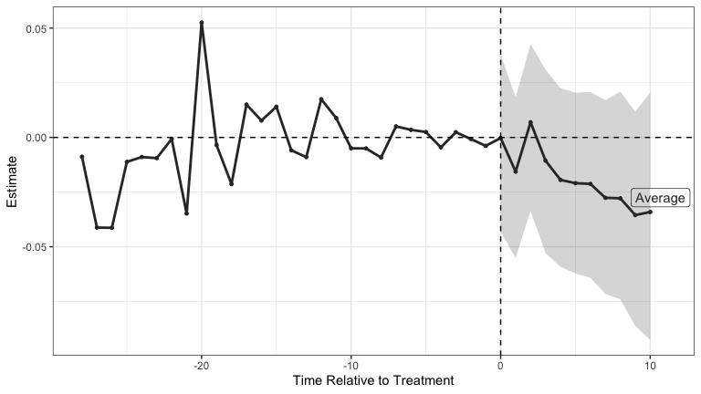

```r
plot(ppool_syn_cov_summ, levels = "Average")
```